# Fitness Tracker Case Study

Deepa

2023-07-11

# Case Study 1 - Bellabeat Wellness Company

The full analysis and relevant files are found on Github. The R files are also available on Kaggle.

## Objective - Help Bellabeat Improve Their Marketing Strategy

The analysis follows the **6 steps of the Data Analysis process** - Ask, Prepare, Process, Analyze, Share and Act.

### 1-Ask - Defining the question

In this phase, we define the problem/hypothesis, determine what metrics to use, and define the success factors.

#### 1.0-Background

Bellabeat is a manufacturer of health focused smart products for women since 2013. Empowering women with knowledge about their own health and habits, Bellabeat has grown rapidly and quickly positioned itself as a tech driven wellness company for females. The co-founder and Chief Creative Officer, Urška Sršen is confident that an analysis of non-Bellabeat consumer data (ie. FitBit fitness tracker usage data) would reveal more opportunities for growth.

#### 1.1-Business Task

Analyze FitBit fitness tracker data to gain insights into how consumers are using the FitBit app and discover trends for Bellabeat marketing strategy.

#### 1.2-Questions to Find Answers to

1. Problem to solve - What should be the marketing strategy of Bellabeat to attract more customers to use its fitness app effectively?
2. Metrics to use - Correlation between number of mins logged on the app and calories burned, number of mins logged and day logged, distance covered and day Descriptive analysis - What are the trends identified?
3. Success criteria - A prescriptive analysis. How could these trends be used to influence Bellabeat marketing strategy?

#### 1.3-Deliverables

1. A clear summary of the business task
2. A description of all data sources used
3. Documentation of any cleaning or manipulation of data
4. A summary of analysis
5. Supporting visualizations and key findings
6. High-level content recommendations based on the analysis
7. A slide deck -
   - Slide 1 - Executive Summary
   - Finding or Big Reveal
   - Key Metrics excavated from data
   - Recommendations
   - Subsequent slides explain the three points mentioned above in detail
   - Also share spreadsheet and SQL queries relevant to the analysis

#### 1.4-Key Stakeholders

- Urška Sršen: Bellabeat’s co founder and Chief Creative Officer
- Sando Mur: Mathematician, Bellabeat’s co founder and key member of the Bellabeat executive team
- Bellabeat marketing analytics team: A team of data analysts guiding Bellabeat’s marketing strategy.

### 3-Process - Cleaning the data

We are using R programming to prepare and process the data

#### 3.1 Setting up enviroment - Installing **Tidyverse** and loading **readr**, **dplyr**, **lubridate**, **ggplot2** packages

```r
#Points to note
#Knitr (engine for dynamic report generation in R used to knit this document) uses CRAN mirror (set of ftp and webservers across the globe with identical, up-to-date, versions of code and documentation for R) to download the packages to be installed.
#When used in interactive sessions such as console of R script, CRAN mirror need not be explicitly mentioned.
#Knitr does automatically assume the CRAN mirror and hence need to be added as repos. The repos attribute has to be added to every install.packages statement
#To avoid installation of packages everytime this file is compiled, add a if condition

if (!require(tidyverse)) install.packages("tidyverse",repos = "http://cran.us.r-project.org")
```

```r
if(!require(plotly)) install.packages("plotly", repos = "http://cran.us.r-project.org")
library(readr)
library(dplyr)
library(lubridate)
library(ggplot2)
library(plotly)
```

#### 3.2 Read the csv file

```r
daily_activity <- read.csv("source-data/dailyActivity_merged.csv")
```

#### 3.3 Data Cleaning and Manipulation

##### Steps

1. Observe and familarize with the values
2. Check for nulls, duplicates, and missing values
3. Perform sanity check

```r
#Preview first 10 rows (default is 6)
daily_activity %>%
  head(10)
```

```
##            Id ActivityDate TotalSteps TotalDistance TrackerDistance
## 1  1503960366    4/12/2016      13162          8.50            8.50
## 2  1503960366    4/13/2016      10735          6.97            6.97
## 3  1503960366    4/14/2016      10460          6.74            6.74
## 4  1503960366    4/15/2016       9762          6.28            6.28
## 5  1503960366    4/16/2016      12669          8.16            8.16
## 6  1503960366    4/17/2016       9705          6.48            6.48
## 7  1503960366    4/18/2016      13019          8.59            8.59
## 8  1503960366    4/19/2016      15506          9.88            9.88
## 9  1503960366    4/20/2016      10544          6.68            6.68
## 10 1503960366    4/21/2016       9819          6.34            6.34
##    LoggedActivitiesDistance VeryActiveDistance ModeratelyActiveDistance
## 1                         0               1.88                     0.55
## 2                         0               1.57                     0.69
## 3                         0               2.44                     0.40
```

[output cut: 29 more lines]

*Finding the missing or null values*

```r
sapply(daily_activity, function(x) sum(is.null(x)))
```

```
##                       Id             ActivityDate               TotalSteps
##                        0                        0                        0
##            TotalDistance          TrackerDistance LoggedActivitiesDistance
##                        0                        0                        0
##       VeryActiveDistance ModeratelyActiveDistance      LightActiveDistance
##                        0                        0                        0
##  SedentaryActiveDistance        VeryActiveMinutes      FairlyActiveMinutes
##                        0                        0                        0
##     LightlyActiveMinutes         SedentaryMinutes                 Calories
##                        0                        0                        0
```

*Basic Description of the data frame*

```r
str(daily_activity)
```

```
## 'data.frame':    940 obs. of  15 variables:
##  $ Id                      : num  1.5e+09 1.5e+09 1.5e+09 1.5e+09 1.5e+09 ...
##  $ ActivityDate            : chr  "4/12/2016" "4/13/2016" "4/14/2016" "4/15/2016" ...
##  $ TotalSteps              : int  13162 10735 10460 9762 12669 9705 13019 15506 10544 9819 ...
##  $ TotalDistance           : num  8.5 6.97 6.74 6.28 8.16 ...
##  $ TrackerDistance         : num  8.5 6.97 6.74 6.28 8.16 ...
##  $ LoggedActivitiesDistance: num  0 0 0 0 0 0 0 0 0 0 ...
##  $ VeryActiveDistance      : num  1.88 1.57 2.44 2.14 2.71 ...
##  $ ModeratelyActiveDistance: num  0.55 0.69 0.4 1.26 0.41 ...
##  $ LightActiveDistance     : num  6.06 4.71 3.91 2.83 5.04 ...
##  $ SedentaryActiveDistance : num  0 0 0 0 0 0 0 0 0 0 ...
##  $ VeryActiveMinutes       : int  25 21 30 29 36 38 42 50 28 19 ...
##  $ FairlyActiveMinutes     : int  13 19 11 34 10 20 16 31 12 8 ...
##  $ LightlyActiveMinutes    : int  328 217 181 209 221 164 233 264 205 211 ...
##  $ SedentaryMinutes        : int  728 776 1218 726 773 539 1149 775 818 838 ...
##  $ Calories                : int  1985 1797 1776 1745 1863 1728 1921 2035 1786 1775 ...
```

*Counting the unique ID to confirm whether data set has 30 IDs.*

```r
length(unique(daily_activity$Id))
```

```
## [1] 33
```

**From the above observation, noted that**

- There is no typo, Null or missing values.
- Data frame has 940 observations and 15 variables.
- ActivityDate is wrongly classified as object data type and has to be converted to datetime data type.
- There are 33 unique IDs, instead of 30 unique IDs as expected from 30 fitness tracker users.

**The following data manipulation is performed**

- Convert ActivityDate to datetime dtype.
- Convert format of ActivityDate to yyyy-mm-dd.
- Create new column DayOfTheWeek by separating the date into day of the week for further analysis.
- Create new column TotalMins being the sum of VeryActiveMinutes, FairlyActiveMinutes, LightlyActiveMinutes and SedentaryMinutes.
- Create new column TotalHours by converting new column in #4 to number of hours.
- Rearrange and rename columns.

**Convert ActivityDate from object to datetime dtype and converting format of ActivityDate to yyyy-mm-dd. Then, printing head to confirm whether it has been updated to datatime64 dtype and dates to yyyy-mm-dd.**

```r
#Print the original column type of ActivityDate
print("Original Data Frame Data Type")
```

```
## [1] "Original Data Frame Data Type"
```

```r
sapply(daily_activity,class)
```

```
##                       Id             ActivityDate               TotalSteps
##                "numeric"              "character"                "integer"
##            TotalDistance          TrackerDistance LoggedActivitiesDistance
##                "numeric"                "numeric"                "numeric"
##       VeryActiveDistance ModeratelyActiveDistance      LightActiveDistance
##                "numeric"                "numeric"                "numeric"
##  SedentaryActiveDistance        VeryActiveMinutes      FairlyActiveMinutes
##                "numeric"                "integer"                "integer"
##     LightlyActiveMinutes         SedentaryMinutes                 Calories
##                "integer"                "integer"                "integer"
```

```r
#Convert the data type of ActivityDate to datetime
#daily_activity[["ActivityDate"]] <- as.POSIXct(daily_activity[['ActivityDate']],"%Y-%m-%d") --> Got the error Error in `as.POSIXlt.character()`: ! character string is not in a standard unambiguous format. It is because R is unable to determine the current format of the variable.
  #One way to fix it is to explicitly calling ActivityDate as character and then applying POSIXct function

#Now convert ActivityDate to datetime
daily_activity[["ActivityDate"]] <- as.POSIXct(as.character(daily_activity[["ActivityDate"]]),format = "%m/%d/%Y")

#Print the modified column type of ActivityDate
print("Converted data frame data type")
```

```
## [1] "Converted data frame data type"
```

```r
sapply(daily_activity, class)
```

```
## $Id
## [1] "numeric"
##
## $ActivityDate
## [1] "POSIXct" "POSIXt"
##
## $TotalSteps
## [1] "integer"
##
## $TotalDistance
## [1] "numeric"
##
## $TrackerDistance
## [1] "numeric"
##
## $LoggedActivitiesDistance
## [1] "numeric"
##
## $VeryActiveDistance
## [1] "numeric"
##
## $ModeratelyActiveDistance
## [1] "numeric"
##
## $LightActiveDistance
## [1] "numeric"
##
## $SedentaryActiveDistance
## [1] "numeric"
##
## $VeryActiveMinutes
## [1] "integer"
##
## $FairlyActiveMinutes
## [1] "integer"
##
## $LightlyActiveMinutes
## [1] "integer"
##
## $SedentaryMinutes
## [1] "integer"
##
## $Calories
## [1] "integer"
```

```r
str(daily_activity)
```

```
## 'data.frame':    940 obs. of  15 variables:
##  $ Id                      : num  1.5e+09 1.5e+09 1.5e+09 1.5e+09 1.5e+09 ...
##  $ ActivityDate            : POSIXct, format: "2016-04-12" "2016-04-13" ...
##  $ TotalSteps              : int  13162 10735 10460 9762 12669 9705 13019 15506 10544 9819 ...
##  $ TotalDistance           : num  8.5 6.97 6.74 6.28 8.16 ...
##  $ TrackerDistance         : num  8.5 6.97 6.74 6.28 8.16 ...
##  $ LoggedActivitiesDistance: num  0 0 0 0 0 0 0 0 0 0 ...
##  $ VeryActiveDistance      : num  1.88 1.57 2.44 2.14 2.71 ...
##  $ ModeratelyActiveDistance: num  0.55 0.69 0.4 1.26 0.41 ...
##  $ LightActiveDistance     : num  6.06 4.71 3.91 2.83 5.04 ...
##  $ SedentaryActiveDistance : num  0 0 0 0 0 0 0 0 0 0 ...
##  $ VeryActiveMinutes       : int  25 21 30 29 36 38 42 50 28 19 ...
##  $ FairlyActiveMinutes     : int  13 19 11 34 10 20 16 31 12 8 ...
##  $ LightlyActiveMinutes    : int  328 217 181 209 221 164 233 264 205 211 ...
##  $ SedentaryMinutes        : int  728 776 1218 726 773 539 1149 775 818 838 ...
##  $ Calories                : int  1985 1797 1776 1745 1863 1728 1921 2035 1786 1775 ...
```

```r
daily_activity %>%
  head(10)
```

```
##            Id ActivityDate TotalSteps TotalDistance TrackerDistance
## 1  1503960366   2016-04-12      13162          8.50            8.50
## 2  1503960366   2016-04-13      10735          6.97            6.97
## 3  1503960366   2016-04-14      10460          6.74            6.74
## 4  1503960366   2016-04-15       9762          6.28            6.28
## 5  1503960366   2016-04-16      12669          8.16            8.16
## 6  1503960366   2016-04-17       9705          6.48            6.48
## 7  1503960366   2016-04-18      13019          8.59            8.59
## 8  1503960366   2016-04-19      15506          9.88            9.88
## 9  1503960366   2016-04-20      10544          6.68            6.68
## 10 1503960366   2016-04-21       9819          6.34            6.34
##    LoggedActivitiesDistance VeryActiveDistance ModeratelyActiveDistance
## 1                         0               1.88                     0.55
## 2                         0               1.57                     0.69
## 3                         0               2.44                     0.40
```

[output cut: 29 more lines]

**Rename Columns for uniformity**

```r
colnames(daily_activity) <- c('id', 'activity_date', 'total_steps', 'total_distance', 'tracker-distance', 'logged_activities_distance', 'very_active_distance', 'moderately_active_distance', 'light_active_distance', 'sedentary_active_distance', 'very_active_minutes', 'fairly_active_minutes', 'lightly_active_minutes', 'sedentary_minutes', 'calories')

print("Data Frame after column name update")
```

```
## [1] "Data Frame after column name update"
```

```r
str(daily_activity)
```

```
## 'data.frame':    940 obs. of  15 variables:
##  $ id                        : num  1.5e+09 1.5e+09 1.5e+09 1.5e+09 1.5e+09 ...
##  $ activity_date             : POSIXct, format: "2016-04-12" "2016-04-13" ...
##  $ total_steps               : int  13162 10735 10460 9762 12669 9705 13019 15506 10544 9819 ...
##  $ total_distance            : num  8.5 6.97 6.74 6.28 8.16 ...
##  $ tracker-distance          : num  8.5 6.97 6.74 6.28 8.16 ...
##  $ logged_activities_distance: num  0 0 0 0 0 0 0 0 0 0 ...
##  $ very_active_distance      : num  1.88 1.57 2.44 2.14 2.71 ...
##  $ moderately_active_distance: num  0.55 0.69 0.4 1.26 0.41 ...
##  $ light_active_distance     : num  6.06 4.71 3.91 2.83 5.04 ...
##  $ sedentary_active_distance : num  0 0 0 0 0 0 0 0 0 0 ...
##  $ very_active_minutes       : int  25 21 30 29 36 38 42 50 28 19 ...
##  $ fairly_active_minutes     : int  13 19 11 34 10 20 16 31 12 8 ...
##  $ lightly_active_minutes    : int  328 217 181 209 221 164 233 264 205 211 ...
##  $ sedentary_minutes         : int  728 776 1218 726 773 539 1149 775 818 838 ...
##  $ calories                  : int  1985 1797 1776 1745 1863 1728 1921 2035 1786 1775 ...
```

**Add new column total mins and total hours**

```r
#Add values using + symbol to add values by row. When sum() was used, the function calculated total sum of all rows instead of by row.
daily_activity$total_mins <- daily_activity$very_active_minutes + daily_activity$fairly_active_minutes + daily_activity$lightly_active_minutes + daily_activity$sedentary_minutes


print("After adding total mins variable")
```

```
## [1] "After adding total mins variable"
```

```r
daily_activity %>%
  select(total_mins,very_active_minutes,fairly_active_minutes,lightly_active_minutes,sedentary_minutes) %>%
    head(5)
```

```
##   total_mins very_active_minutes fairly_active_minutes lightly_active_minutes
## 1       1094                  25                    13                    328
## 2       1033                  21                    19                    217
## 3       1440                  30                    11                    181
## 4        998                  29                    34                    209
## 5       1040                  36                    10                    221
##   sedentary_minutes
## 1               728
## 2               776
## 3              1218
## 4               726
## 5               773
```

```r
daily_activity['total_hrs'] <- round(daily_activity$total_mins/60,0)

print("After adding total hours variable")
```

```
## [1] "After adding total hours variable"
```

```r
daily_activity %>%
  select (total_hrs, total_mins) %>%
  head(5)
```

```
##   total_hrs total_mins
## 1        18       1094
## 2        17       1033
## 3        24       1440
## 4        17        998
## 5        17       1040
```

**Add new column to capture day of the week corresponding to activity date**

```r
daily_activity$day_of_week <- weekdays(as.Date(daily_activity$activity_date))

print("Data frame after adding new variable")
```

```
## [1] "Data frame after adding new variable"
```

```r
daily_activity %>%
 head(10)
```

```
##            id activity_date total_steps total_distance tracker-distance
## 1  1503960366    2016-04-12       13162           8.50             8.50
## 2  1503960366    2016-04-13       10735           6.97             6.97
## 3  1503960366    2016-04-14       10460           6.74             6.74
## 4  1503960366    2016-04-15        9762           6.28             6.28
## 5  1503960366    2016-04-16       12669           8.16             8.16
## 6  1503960366    2016-04-17        9705           6.48             6.48
## 7  1503960366    2016-04-18       13019           8.59             8.59
## 8  1503960366    2016-04-19       15506           9.88             9.88
## 9  1503960366    2016-04-20       10544           6.68             6.68
## 10 1503960366    2016-04-21        9819           6.34             6.34
##    logged_activities_distance very_active_distance moderately_active_distance
## 1                           0                 1.88                       0.55
## 2                           0                 1.57                       0.69
## 3                           0                 2.44                       0.40
```

[output cut: 40 more lines]

### 4-Analyze - Analyzing the data

```r
daily_activity %>%
  summary()
```

```
##        id            activity_date                     total_steps
##  Min.   :1.504e+09   Min.   :2016-04-12 00:00:00.00   Min.   :    0
##  1st Qu.:2.320e+09   1st Qu.:2016-04-19 00:00:00.00   1st Qu.: 3790
##  Median :4.445e+09   Median :2016-04-26 00:00:00.00   Median : 7406
##  Mean   :4.855e+09   Mean   :2016-04-26 06:53:37.01   Mean   : 7638
##  3rd Qu.:6.962e+09   3rd Qu.:2016-05-04 00:00:00.00   3rd Qu.:10727
##  Max.   :8.878e+09   Max.   :2016-05-12 00:00:00.00   Max.   :36019
##  total_distance   tracker-distance logged_activities_distance
##  Min.   : 0.000   Min.   : 0.000   Min.   :0.0000
##  1st Qu.: 2.620   1st Qu.: 2.620   1st Qu.:0.0000
##  Median : 5.245   Median : 5.245   Median :0.0000
##  Mean   : 5.490   Mean   : 5.475   Mean   :0.1082
##  3rd Qu.: 7.713   3rd Qu.: 7.710   3rd Qu.:0.0000
##  Max.   :28.030   Max.   :28.030   Max.   :4.9421
##  very_active_distance moderately_active_distance light_active_distance
##  Min.   : 0.000       Min.   :0.0000             Min.   : 0.000
##  1st Qu.: 0.000       1st Qu.:0.0000             1st Qu.: 1.945
##  Median : 0.210       Median :0.2400             Median : 3.365
##  Mean   : 1.503       Mean   :0.5675             Mean   : 3.341
##  3rd Qu.: 2.053       3rd Qu.:0.8000             3rd Qu.: 4.782
##  Max.   :21.920       Max.   :6.4800             Max.   :10.710
##  sedentary_active_distance very_active_minutes fairly_active_minutes
##  Min.   :0.000000          Min.   :  0.00      Min.   :  0.00
##  1st Qu.:0.000000          1st Qu.:  0.00      1st Qu.:  0.00
##  Median :0.000000          Median :  4.00      Median :  6.00
##  Mean   :0.001606          Mean   : 21.16      Mean   : 13.56
##  3rd Qu.:0.000000          3rd Qu.: 32.00      3rd Qu.: 19.00
##  Max.   :0.110000          Max.   :210.00      Max.   :143.00
##  lightly_active_minutes sedentary_minutes    calories      total_mins
##  Min.   :  0.0          Min.   :   0.0    Min.   :   0   Min.   :   2.0
##  1st Qu.:127.0          1st Qu.: 729.8    1st Qu.:1828   1st Qu.: 989.8
##  Median :199.0          Median :1057.5    Median :2134   Median :1440.0
##  Mean   :192.8          Mean   : 991.2    Mean   :2304   Mean   :1218.8
##  3rd Qu.:264.0          3rd Qu.:1229.5    3rd Qu.:2793   3rd Qu.:1440.0
##  Max.   :518.0          Max.   :1440.0    Max.   :4900   Max.   :1440.0
##    total_hrs     day_of_week
##  Min.   : 0.00   Length:940
##  1st Qu.:16.00   Class :character
##  Median :24.00   Mode  :character
##  Mean   :20.31
##  3rd Qu.:24.00
##  Max.   :24.00
```

### 5-Share - Visualizing & Sharing your results

In this step, we are creating visualizations to communicate our findings based on our analysis.

#### 5.1 Data Visualization

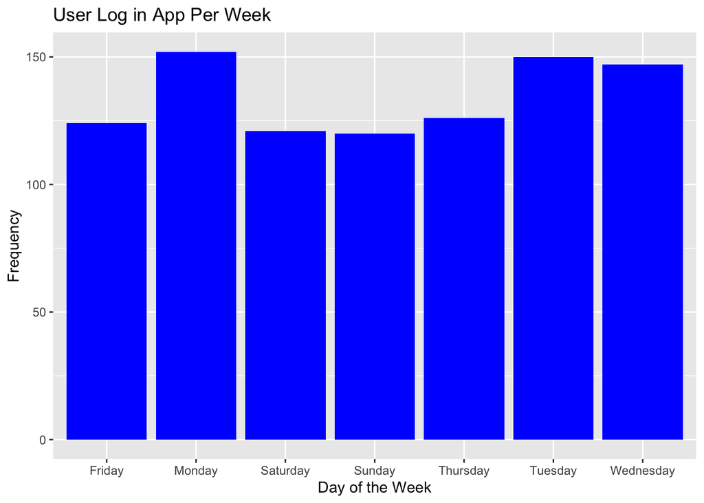

*Frequency of usage across the week*

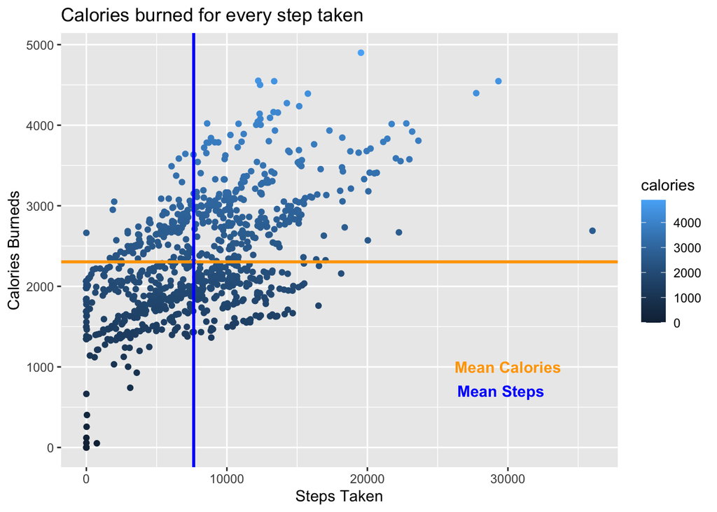

*Calories burned for every step taken*

From the scatter plot, we discovered that:

- It is a positive correlation.
- We observed that intensity of calories burned increase when users are at the range of > 0 to 15,000 steps with calories burn rate cooling down from 15,000 steps onwards.
- Noted a few outliers:
  - Zero steps with zero to minimal calories burned.
  - 1 observation of > 35,000 steps with < 3,000 calories burned.
  - Deduced that outliers could be due to natural variation of data, change in user’s usage or errors in data collection (ie. miscalculations, data contamination or human error).

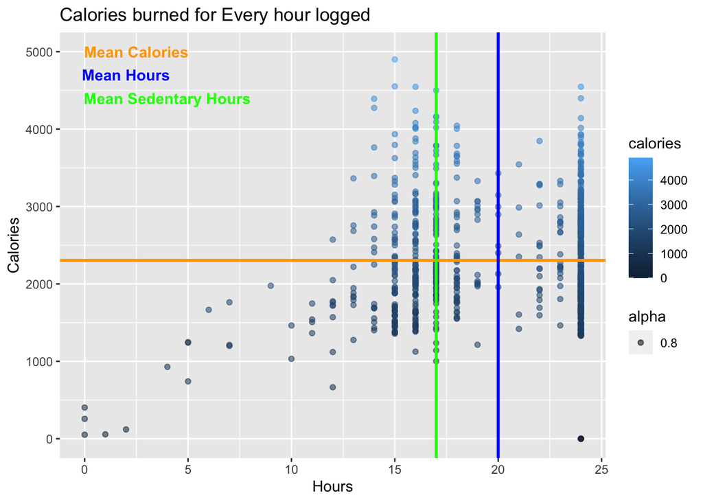

*Calories burned for every hour logged*

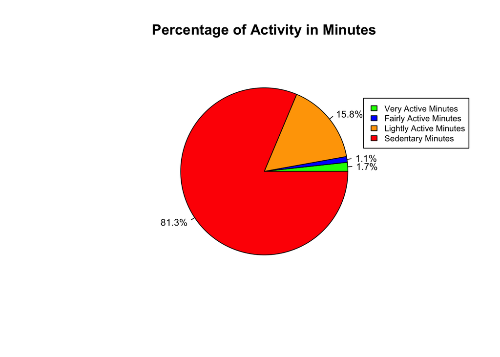

*Percentage of Activity in Minutes*

As seen from the pie chart,

- Sedentary minutes takes the biggest slice at 81.3%.
- This indicates that users are using the fitness app to log daily activities such as daily commute, inactive movements or running errands.
- App is rarely being used to track fitness (ie. running) as per the minor percentage of fairly active activity (1.1%) and very active activity (1.7%).

### 6 - Act

In the final step, we will be delivering our insights and providing recommendations based on our analysis.